# Chapter 6 - Longitudinal analysis

Seppo Nyrkkö *Fri Dec 4, 2020*

## Reading the data in.

```r
library(ggplot2)
library(dplyr)
library(tidyr)

# Rats diet weighting data in long format
longrats <- read.csv("data/ratslong.csv")

# BPRS patient treatment scores
longbprs <- read.csv("data/bprslong.csv")
```

## i) RATS analysis

```r
summary(longrats)
```

```
##        ID       Group         days           weight
##  rat-1  : 11   Grp1:88   Min.   : 1.00   Min.   :225.0
##  rat-10 : 11   Grp2:44   1st Qu.:15.00   1st Qu.:267.0
##  rat-11 : 11   Grp3:44   Median :36.00   Median :344.5
##  rat-12 : 11             Mean   :33.55   Mean   :384.5
##  rat-13 : 11             3rd Qu.:50.00   3rd Qu.:511.2
##  rat-14 : 11             Max.   :64.00   Max.   :628.0
##  (Other):110
```

```r
str(longrats)
```

```
## 'data.frame':    176 obs. of  4 variables:
##  $ ID    : Factor w/ 16 levels "rat-1","rat-10",..: 1 9 10 11 12 13 14 15 16 2 ...
##  $ Group : Factor w/ 3 levels "Grp1","Grp2",..: 1 1 1 1 1 1 1 1 2 2 ...
##  $ days  : int  1 1 1 1 1 1 1 1 1 1 ...
##  $ weight: int  240 225 245 260 255 260 275 245 410 405 ...
```

### Quick summary of the long data (Rats):

- Rats have unique IDs.
- Control group category (factorized) is the diet Group
- Time axis is numeric in days
- Longitudinal measurements are weights

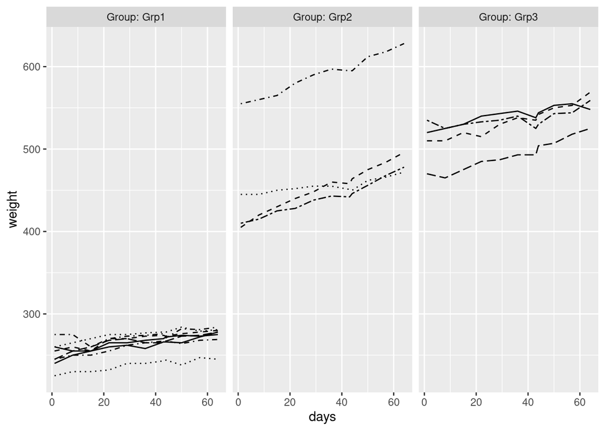

```r
#  Some ggplots

# Display the data graphically, first by groups.

ggplot(longrats, aes(x = days, y = weight, linetype = ID)) +
  geom_line() +
  scale_linetype_manual(values = rep(1:10, times=4)) +
  facet_grid(. ~ Group, labeller = label_both) +
  theme(legend.position = "none") +
  scale_y_continuous(limits = c(min(longrats$weight), max(longrats$weight)))
```

Seems like the grouping is done and handled correctly. Time goes in the right direction and weight grows as the days pass.

Group 1 doesn’t gain weight as much as groups 2 and 3. An outlier rat in group 2 is a bit heavier but still belongs to the correct diet group.

Since the initial weights differ so much we can understand better the effects of the diets by standardizing the data

```r
# Standardizing = zero mean, unit = standard deviance
longrats <- longrats %>%
  group_by(days) %>%
  mutate(stdWeight = (weight - mean(weight)) / sd(weight)) %>%
  ungroup()
str(longrats)
```

```
## Classes 'tbl_df', 'tbl' and 'data.frame':    176 obs. of  5 variables:
##  $ ID       : Factor w/ 16 levels "rat-1","rat-10",..: 1 9 10 11 12 13 14 15 16 2 ...
##  $ Group    : Factor w/ 3 levels "Grp1","Grp2",..: 1 1 1 1 1 1 1 1 2 2 ...
##  $ days     : int  1 1 1 1 1 1 1 1 1 1 ...
##  $ weight   : int  240 225 245 260 255 260 275 245 410 405 ...
##  $ stdWeight: num  -1.001 -1.12 -0.961 -0.842 -0.882 ...
```

This seems to adjust our weights per normal growth. Again, graphically:

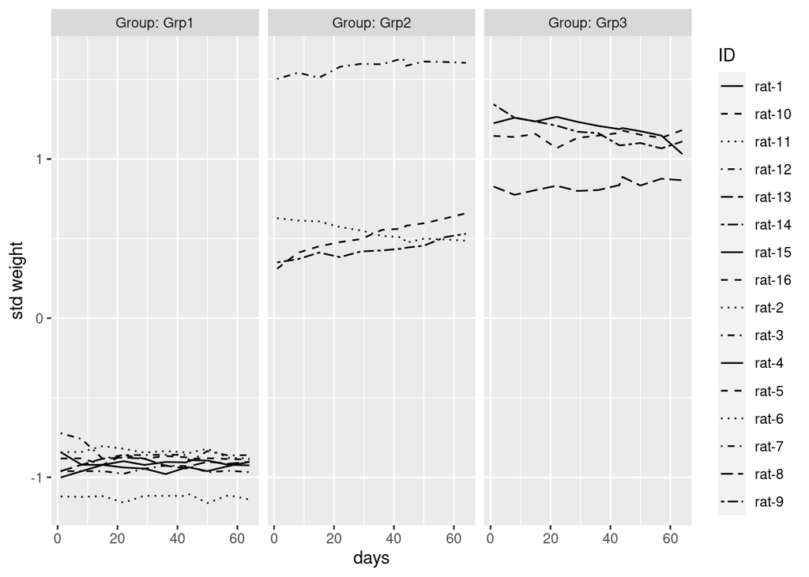

```r
ggplot(longrats, aes(x = days, y = stdWeight, linetype = ID)) +
  geom_line() +
  scale_linetype_manual(values = rep(1:10, times=4)) +
  facet_grid(. ~ Group, labeller = label_both) +
  scale_y_continuous(name = "std weight")
```

Now calculate the group means and errors.

```r
# some fancy pipelining
ratgroups <- longrats %>%
  group_by(Group, days) %>%
  summarise(mean = mean(weight), se = sd(weight) / sqrt(length(weight))) %>%
  ungroup()

summary(ratgroups)
```

```
##   Group         days            mean             se
##  Grp1:11   Min.   : 1.00   Min.   :250.6   Min.   : 3.604
##  Grp2:11   1st Qu.:15.00   1st Qu.:269.5   1st Qu.: 4.809
##  Grp3:11   Median :36.00   Median :486.5   Median :12.202
##            Mean   :33.55   Mean   :424.7   Mean   :17.149
##            3rd Qu.:50.00   3rd Qu.:518.2   3rd Qu.:34.903
##            Max.   :64.00   Max.   :550.2   Max.   :37.129
```

```r
dim(ratgroups)
```

```
## [1] 33  4
```

Now we get a graphical analysis how the groups react to the diets per days run:

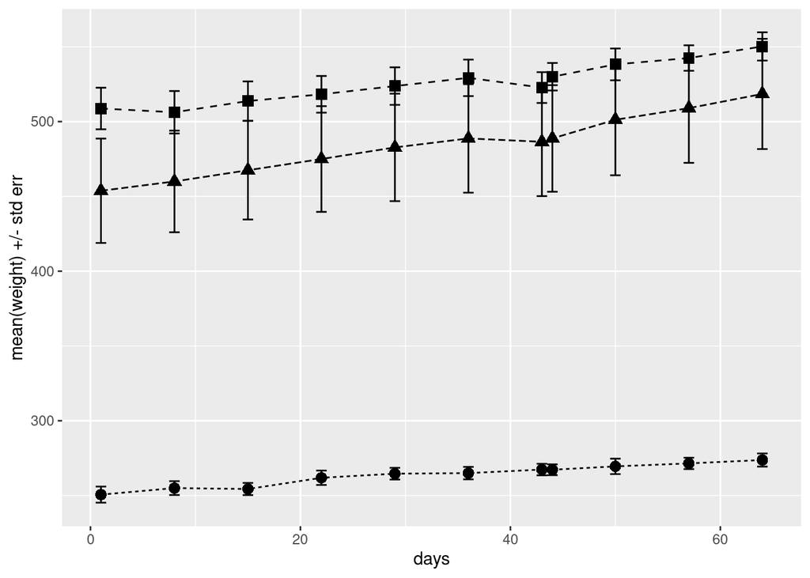

```r
ggplot(ratgroups,
  aes(x = days, y = mean, linetype = Group, shape = Group)) +
  geom_line() +
  geom_point(size=3) +
  geom_errorbar(aes(ymin=mean-se, ymax=mean+se, linetype="2"), width=1) +
  theme(legend.position = c(0.8,0.8,0.8)) +
  scale_y_continuous(name = "mean(weight) +/- std err")
```

To validate our rats, we can do the boxplot with error bars to visually determine whether our weight groups are okay or if they contain outlier rats.

```r
ratbox <- longrats %>%
  filter(days > 1) %>%
  group_by(Group, ID) %>%
  summarise(mean=mean(weight) ) %>%
  ungroup()
```

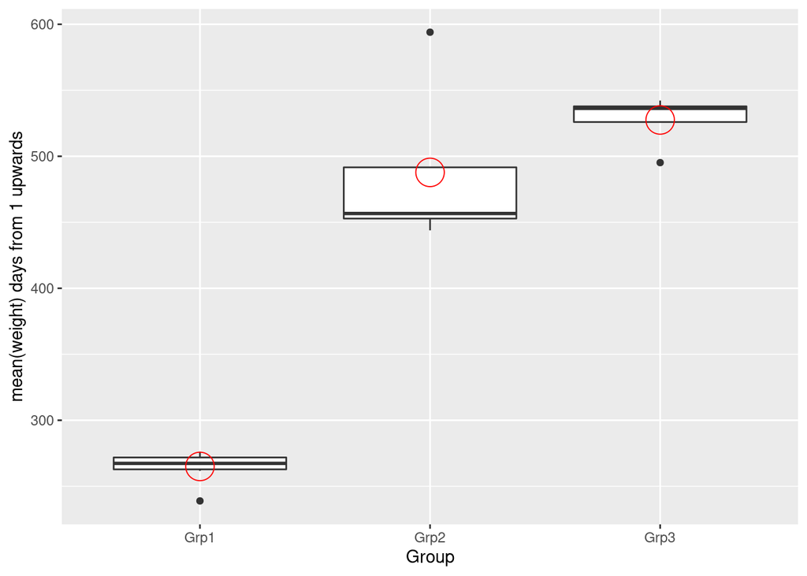

```r
ggplot(ratbox, aes(x = Group, y = mean)) +
  geom_boxplot() +
  stat_summary(fun = "mean", geom = "point", shape=1, size=8, fill = "white", col="red") +
  scale_y_continuous(name = "mean(weight) days from 1 upwards")
```

```r
summary(ratbox$Group)
```

```
## Grp1 Grp2 Grp3
##    8    4    4
```

Since there are only 4 rats in groups 2 and 3, it’s really hard to say if there are any outliers. We are happy with the one suspiciously heavy rat in group 2.

**Let’s continue to the hypothesis testing then.** The first question is whether the mean weight of group 1 differs from others.

```r
# Two-sample t-test
ratbox$isGrp1 <- ratbox$Group=="Grp1"
t.test(mean ~ isGrp1, data=ratbox, var.equal=T)
```

```
##
##  Two Sample t-test
##
## data:  mean by isGrp1
## t = 12.628, df = 14, p-value = 4.848e-09
## alternative hypothesis: true difference in means is not equal to 0
## 95 percent confidence interval:
##  201.416 283.834
## sample estimates:
## mean in group FALSE  mean in group TRUE
##             507.650             265.025
```

**Now adding a initial weight from the first day before the diets**

```r
# Since we are interested in the growth profile of these rats we take in account
# the day 1 weight

ratinit <- longrats %>%
  filter(days == 1) %>%
  group_by(Group, ID) %>%
  summarise(initialW=mean(weight) ) %>%
  ungroup()

ratbox$initialW=ratinit$initialW

fit <- lm(mean ~ initialW + isGrp1, data=ratbox)
fit
```

```
##
## Call:
## lm(formula = mean ~ initialW + isGrp1, data = ratbox)
##
## Coefficients:
## (Intercept)     initialW   isGrp1TRUE
##     86.4844       0.8751     -40.7937
```

```r
anova(fit)
```

```
## Analysis of Variance Table
##
## Response: mean
##           Df Sum Sq Mean Sq   F value    Pr(>F)
## initialW   1 253625  253625 1806.5913 2.448e-15 ***
## isGrp1     1    690     690    4.9159   0.04505 *
## Residuals 13   1825     140
## ---
## Signif. codes:  0 '***' 0.001 '**' 0.01 '*' 0.05 '.' 0.1 ' ' 1
```

It seems like the group 1 has a 95% confidence to be of a different growth profile. The visual examination supports this interpretation.

## ii) BPRS analysis

```r
str(longbprs)
```

```
## 'data.frame':    360 obs. of  4 variables:
##  $ treatment: Factor w/ 2 levels "T1","T2": 1 1 1 1 1 1 1 1 1 1 ...
##  $ subject  : Factor w/ 40 levels "G1P1","G1P10",..: 1 12 14 15 16 17 18 19 20 2 ...
##  $ weeks    : int  0 0 0 0 0 0 0 0 0 0 ...
##  $ bprs     : int  42 58 54 55 72 48 71 30 41 57 ...
```

```r
summary(longbprs)
```

```
##  treatment    subject        weeks        bprs
##  T1:180    G1P1   :  9   Min.   :0   Min.   :18.00
##  T2:180    G1P10  :  9   1st Qu.:2   1st Qu.:27.00
##            G1P11  :  9   Median :4   Median :35.00
##            G1P12  :  9   Mean   :4   Mean   :37.66
##            G1P13  :  9   3rd Qu.:6   3rd Qu.:43.00
##            G1P14  :  9   Max.   :8   Max.   :95.00
##            (Other):306
```

### Quick summary of the long data:

- Subjects have unique subject-IDs (factorized).
- Group category is the treatment id (factorized)
- Time axis is numeric in weeks
- Measurements are bprs score

```r
glimpse(longbprs)
```

```
## Observations: 360
## Variables: 4
## $ treatment <fct> T1, T1, T1, T1, T1, T1, T1, T1, T1, T1, T1, T1, T1, T1, T1,…
## $ subject   <fct> G1P1, G1P2, G1P3, G1P4, G1P5, G1P6, G1P7, G1P8, G1P9, G1P10…
## $ weeks     <int> 0, 0, 0, 0, 0, 0, 0, 0, 0, 0, 0, 0, 0, 0, 0, 0, 0, 0, 0, 0,…
## $ bprs      <int> 42, 58, 54, 55, 72, 48, 71, 30, 41, 57, 30, 55, 36, 38, 66,…
```

```r
summary(longbprs)
```

```
##  treatment    subject        weeks        bprs
##  T1:180    G1P1   :  9   Min.   :0   Min.   :18.00
##  T2:180    G1P10  :  9   1st Qu.:2   1st Qu.:27.00
##            G1P11  :  9   Median :4   Median :35.00
##            G1P12  :  9   Mean   :4   Mean   :37.66
##            G1P13  :  9   3rd Qu.:6   3rd Qu.:43.00
##            G1P14  :  9   Max.   :8   Max.   :95.00
##            (Other):306
```

Let’s visually analyze the BPRS study groups:

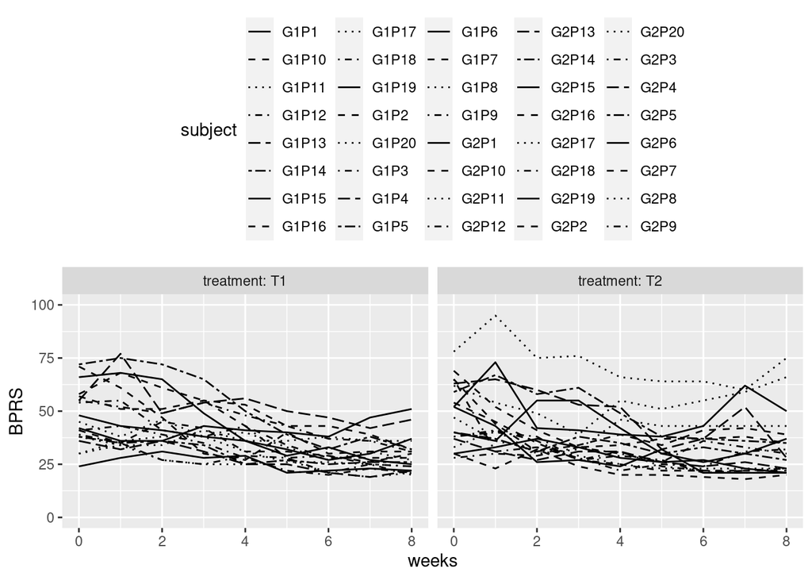

```r
ggplot(longbprs, aes(x=weeks, y=bprs, linetype=subject)) +
  geom_line() +
  scale_linetype_manual(values=rep(1:10, times=4)) +
  facet_grid(. ~ treatment, labeller=label_both) +
  scale_y_continuous(name="BPRS", limits=c(0,100)) +
  theme(legend.position="top")
```

Okay this looks really good. At least the data is read in correctly and this correlates to what we read in from the original bprs survey data.

We cannot be exactly sure whether the scores go down with the treatment T1 group, but let’s continue with the analysis. The variance in T2 scores makes it difficult to visually compare the trend during the treatment weeks.

Let’s try some regression modeling

```r
bprsreg <- lm(bprs ~ weeks + treatment, data=longbprs)
summary(bprsreg)
```

```
##
## Call:
## lm(formula = bprs ~ weeks + treatment, data = longbprs)
##
## Residuals:
##     Min      1Q  Median      3Q     Max
## -22.454  -8.965  -3.196   7.002  50.244
##
## Coefficients:
##             Estimate Std. Error t value Pr(>|t|)
## (Intercept)  46.4539     1.3670  33.982   <2e-16 ***
## weeks        -2.2704     0.2524  -8.995   <2e-16 ***
## treatmentT2   0.5722     1.3034   0.439    0.661
## ---
## Signif. codes:  0 '***' 0.001 '**' 0.01 '*' 0.05 '.' 0.1 ' ' 1
##
## Residual standard error: 12.37 on 357 degrees of freedom
## Multiple R-squared:  0.1851, Adjusted R-squared:  0.1806
## F-statistic: 40.55 on 2 and 357 DF,  p-value: < 2.2e-16
```

This doesn’t show yet any significance of the treatment, as regards to the group means, but the weeks undergone seems to be a significant variable.

Since the observations are from repeating individuals, we would like to introduce some **mixed models** here. We can try to see whether we allow the **unique subject id** to count as a *random effect*:

```r
library(lme4)
# Random intercept model per subject:

bprs_sub <- lmer(bprs ~ weeks + treatment + (1 | subject), data=longbprs, REML = F)
summary(bprs_sub)
```

```
## Linear mixed model fit by maximum likelihood  ['lmerMod']
## Formula: bprs ~ weeks + treatment + (1 | subject)
##    Data: longbprs
##
##      AIC      BIC   logLik deviance df.resid
##   2582.9   2602.3  -1286.5   2572.9      355
##
## Scaled residuals:
##      Min       1Q   Median       3Q      Max
## -2.27506 -0.59909 -0.06104  0.44226  3.15835
##
## Random effects:
##  Groups   Name        Variance Std.Dev.
##  subject  (Intercept) 97.39    9.869
##  Residual             54.23    7.364
## Number of obs: 360, groups:  subject, 40
##
## Fixed effects:
##             Estimate Std. Error t value
## (Intercept)  46.4539     2.3521  19.750
## weeks        -2.2704     0.1503 -15.104
## treatmentT2   0.5722     3.2159   0.178
##
## Correlation of Fixed Effects:
##             (Intr) weeks
## weeks       -0.256
## treatmentT2 -0.684  0.000
```

```r
# Now random intercept and ALSO A random slope model

bprs_subweek <- lmer(bprs ~ weeks + treatment + (weeks | subject), data=longbprs, REML = F)
summary(bprs_subweek)
```

```
## Linear mixed model fit by maximum likelihood  ['lmerMod']
## Formula: bprs ~ weeks + treatment + (weeks | subject)
##    Data: longbprs
##
##      AIC      BIC   logLik deviance df.resid
##   2523.2   2550.4  -1254.6   2509.2      353
##
## Scaled residuals:
##     Min      1Q  Median      3Q     Max
## -2.4655 -0.5150 -0.0920  0.4347  3.7353
##
## Random effects:
##  Groups   Name        Variance Std.Dev. Corr
##  subject  (Intercept) 167.827  12.955
##           weeks         2.331   1.527   -0.67
##  Residual              36.747   6.062
## Number of obs: 360, groups:  subject, 40
##
## Fixed effects:
##             Estimate Std. Error t value
## (Intercept)  45.9830     2.6470  17.372
## weeks        -2.2704     0.2713  -8.370
## treatmentT2   1.5139     3.1392   0.482
##
## Correlation of Fixed Effects:
##             (Intr) weeks
## weeks       -0.545
## treatmentT2 -0.593  0.000
```

**Notice the higher estimate of treatmentT2** – This may prove to be significant.

The week-based individual slope has quite a big effect (variance at around 2).

Now let’s run an ANOVA test against these two random effects models

```r
anova(bprs_sub, bprs_subweek)
```

```
## Data: longbprs
## Models:
## bprs_sub: bprs ~ weeks + treatment + (1 | subject)
## bprs_subweek: bprs ~ weeks + treatment + (weeks | subject)
##              npar    AIC    BIC  logLik deviance  Chisq Df Pr(>Chisq)
## bprs_sub        5 2582.9 2602.3 -1286.5   2572.9
## bprs_subweek    7 2523.2 2550.4 -1254.6   2509.2 63.663  2  1.499e-14 ***
## ---
## Signif. codes:  0 '***' 0.001 '**' 0.01 '*' 0.05 '.' 0.1 ' ' 1
```

**We would like to conclude that the model which takes the subject id and the personal slope as a random effect fits the data quite well!**

Let’s plot the fitted curves to examine this visually

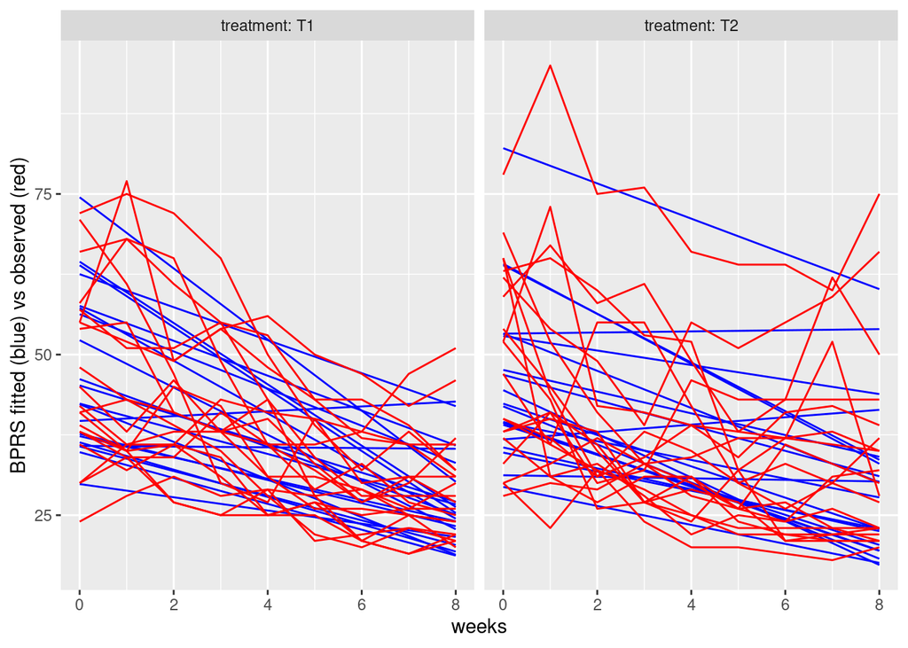

```r
# Compute the fitted values
Fitted <- fitted(bprs_subweek, longbprs)

# Add a new column for the fitted data
bprslongfit <- mutate(longbprs, bprs=Fitted)

# Draw a plot of bprs (fitted and observed)
ggplot(bprslongfit, aes(x=weeks, y=bprs, group=subject)) +
  geom_line(color="blue") +
  geom_line(data=longbprs,color="red") +
  scale_x_continuous(name="weeks") +
  facet_grid(. ~ treatment, labeller=label_both) +
  scale_y_continuous(name="BPRS fitted (blue) vs observed (red)") +
  theme(legend.position="top")
```